# Interaktive Karten

Jan-Philipp Kolb

23 November 2017

## Die Daten - Weltkulturerbe

- die Daten einlesen:

```r
url <- "https://raw.githubusercontent.com/Japhilko/
GeoData/master/2015/data/whcSites.csv"

whcSites <- read.csv(url)
```

- die Daten werden eingeschränkt:

```r
whcSitesDat <- with(whcSites,data.frame(name_en,category))
```

## Eine erste interaktive Tabelle - [Das Paket `DT`](https://rstudio.github.io/DT/)

```r
install.packages("DT")
```

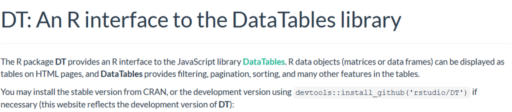

## Weitere Variablen WHC Datensatz

```r
whcSitesDat2 <- with(whcSites,data.frame(name_en,category,
                                         longitude,latitude,date_inscribed,area_hectares,danger_list))
```

- mit dem Befehl `datatable` kann man eine erste interaktive Tabelle erstellen:

```r
library('DT')
datatable(whcSitesDat2)
```

|  | name_en | category | longitude | latitude | date_inscribed | area_hectares | danger_list |
| --- | --- | --- | --- | --- | --- | --- | --- |
| 1 | Cultural Landscape and Archaeological Remains of the Bamiyan Valley | Cultural | 67.82525 | 34.84694 | 2003 | 158.9265 | Y 2003 |
| 2 | Minaret and Archaeological Remains of Jam | Cultural | 64.51605556 | 34.39655556 | 2002 | 70 | Y 2002 |
| 3 | Historic Centres of Berat and Gjirokastra | Cultural | 20.13333333 | 40.06944444 | 2005 | 58.9 |  |
| 4 | Butrint | Cultural | 20.02611111 | 39.75111111 | 1992 |  |  |
| 5 | Al Qal'a of Beni Hammad | Cultural | 4.78684 | 35.81844 | 1980 | 150 |  |
| 6 | M'Zab Valley | Cultural | 3.68333 | 32.48333 | 1982 | 665.03 |  |
| 7 | DjÃ©mila | Cultural | 5.73667 | 36.32056 | 1982 | 30.6 |  |
| 8 | Timgad | Cultural | 6.63333 | 35.45 | 1982 | 90.54 |  |
| 9 | Kasbah of Algiers | Cultural | 3.06028 | 36.78333 | 1992 | 60 |  |
| 10 | Madriu-Perafita-Claror Valley | Cultural | 1.595555556 | 42.49472222 | 2004 | 4247 |  |

[output cut: 1021 more lines]

## Das Ergebnis bei Rpubs

http://rpubs.com/Japhilko82/WHCdata

[figure not shown]

## Das Paket `magrittr`

- [magrittr](https://cran.r-project.org/web/packages/magrittr/index.html) - für den Pipe Operator in R:

```r
install.packages("magrittr")
```

```r
library("magrittr")
```

[figure not shown]

## [Die Pipes nutzen](https://www.r-bloggers.com/more-readable-code-with-pipes-in-r/)

```r
library(magrittr)

str1 <- "Hallo Welt"
str1 %>% substr(1,5)
```

```
## [1] "Hallo"
```

```r
str1 %>% substr(1,5) %>% toupper()
```

```
## [1] "HALLO"
```

## Das Paket `leaflet`

- [`leaflet`](https://rstudio.github.io/leaflet/) - um interaktive Karten mit der JavaScript Bibliothek `leaflet` zu erzeugen

```r
install.packages("leaflet")
```

```r
library("leaflet")
```

- Bei `leaflet` wird mit so genannten Tiles gearbeitet.
- Robin Lovelace - [The leaflet package for online mapping in R](http://robinlovelace.net/r/2015/02/01/leaflet-r-package.html)

## Eine interaktive Karte erstellen

```r
m <- leaflet() %>%
  addProviderTiles("Esri.NatGeoWorldMap") %>%
  addMarkers(lng=whcSites$lon,
             lat=whcSites$lat,
             popup=whcSites$name_en)
```

## [Die Karte zeigen](https://rpubs.com/Japhilko82/WorldHeritageSites)

```r
m
```

[interactive chart not shown]

## Farbe hinzu

- die unterschiedlichen Kategorien farblich einfärben

```r
whcSites$color <- "red"
whcSites$color[whcSites$category=="Cultural"] <- "blue"
whcSites$color[whcSites$category=="Mixed"] <- "orange"
```

### Eine Karte mit Farbe erzeugen

```r
m1 <- leaflet() %>%
  addProviderTiles("Esri.NatGeoWorldMap") %>%
  addCircles(lng=whcSites$lon,
             lat=whcSites$lat,
             popup=whcSites$name_en,
             color=whcSites$color)
```

## [Die Karte mit mehr Farbe](https://rpubs.com/Japhilko82/CatWHS)

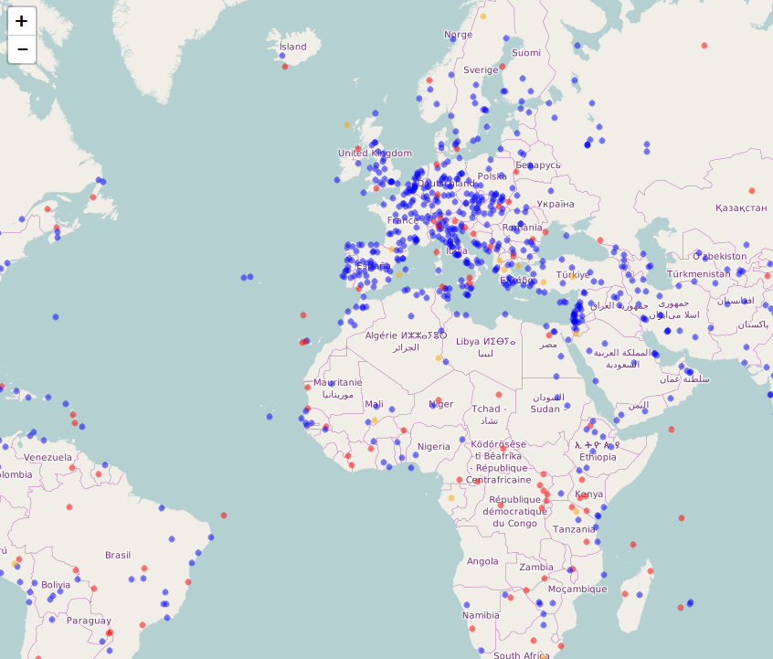

Weltkulturerbe

## [Die Karte abspeichern](http://www.r-bloggers.com/interactive-mapping-with-leaflet-in-r-2/)

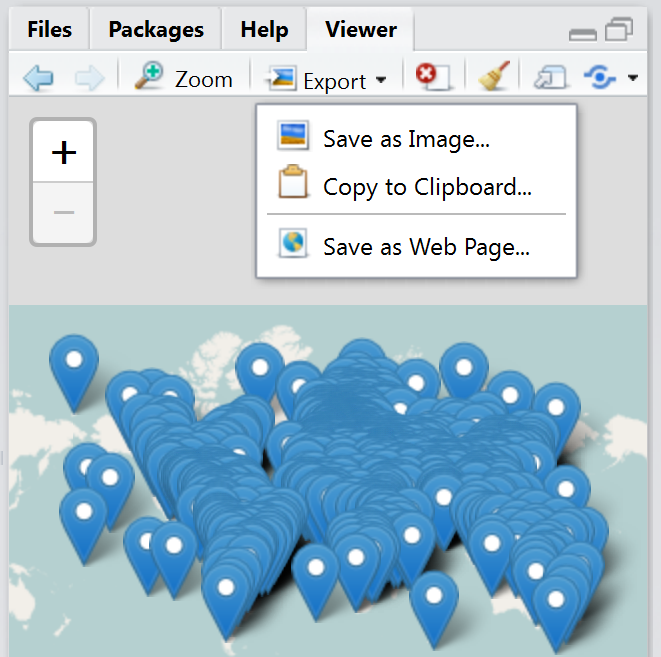

## [Layers ein- und ausblenden](https://rstudio.github.io/leaflet/showhide.html)

```r
m2 <- leaflet() %>%
  addTiles(group = "OSM (default)") %>%
  addProviderTiles("Stamen.Toner", group = "Toner") %>%
  addProviderTiles("Stamen.TonerLite", group = "Toner Lite") %>%

  addCircles(lng=whcSites$lon,
             lat=whcSites$lat,
             popup=whcSites$name_en) %>%

  addLayersControl(
    baseGroups = c("OSM (default)", "Toner", "Toner Lite"),
    options = layersControlOptions(collapsed = FALSE)
  )
m2
```

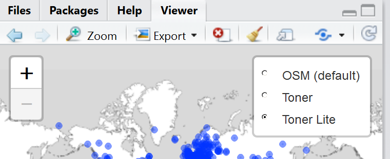

## [Ein weiteres Beispiel mit Erdbebendaten](https://rstudio.github.io/leaflet/showhide.html)

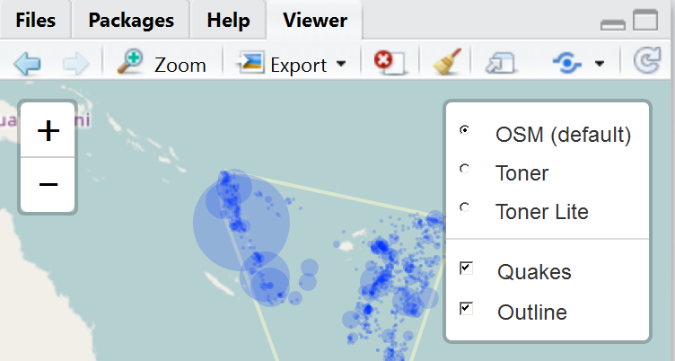

```r
outline <- quakes[chull(quakes$long, quakes$lat),]
```

```r
map <- leaflet(quakes) %>%
  # Base groups
  addTiles(group = "OSM (default)") %>%
  addProviderTiles("Stamen.Toner", group = "Toner") %>%
  addProviderTiles("Stamen.TonerLite", group = "Toner Lite") %>%
  # Overlay groups
  addCircles(~long, ~lat, ~10^mag/5, stroke = F, group = "Quakes") %>%
  addPolygons(data = outline, lng = ~long, lat = ~lat,
    fill = F, weight = 2, color = "#FFFFCC", group = "Outline") %>%
  # Layers control
  addLayersControl(
    baseGroups = c("OSM (default)", "Toner", "Toner Lite"),
    overlayGroups = c("Quakes", "Outline"),
    options = layersControlOptions(collapsed = FALSE)
  )
map
```

## Beispiel US Staaten

```r
library(maps)
mapStates = map("state", fill = TRUE, plot = FALSE)
leaflet(data = mapStates) %>% addTiles() %>%
  addPolygons(fillColor = topo.colors(10, alpha = NULL))
```

[interactive chart not shown]

## Der Befehl `setView`

- mit `setView` kann man bestimmen welchen Ausschnitt man für die Hintergrundkarte haben möchte
- dazu muss man die latitude und Longitude Koordinaten und ein zoom Level angegeben
- dabei kann man nur ganze Zahlen angeben
- je kleiner die Zahl, desto größer ist der Kartenausschnitt:
- level 3 - Kontinent
- level 10 - Stadt
- level 21 - Gebäude

## Die Basiskarte ändern

- Neben der Default Basiskarte kann man auch [andere Hintergründe aktivieren](http://leaflet-extras.github.io/leaflet-providers/preview/index.html)

```r
m <- leaflet() %>% setView(lng = 9.180501, lat = 48.77814, zoom = 12)
m %>% addProviderTiles("Stamen.Toner")
```

[interactive chart not shown]

## Basiskarte - CartoDB

```r
m %>% addProviderTiles("CartoDB.Positron")
```

[interactive chart not shown]

## Esri.NatGeoWorldMap

```r
m %>% addProviderTiles("Esri.NatGeoWorldMap")
```

[interactive chart not shown]

## OpenTopoMap

```r
m %>% addProviderTiles("OpenTopoMap")
```

[interactive chart not shown]

## Thunderforest.OpenCycleMap

```r
m %>% addProviderTiles("Thunderforest.OpenCycleMap")
```

[interactive chart not shown]

## Cluster Optionen für Marker

```r
leaflet(quakes) %>%
addProviderTiles("Esri.NatGeoWorldMap") %>%
addMarkers(
  clusterOptions = markerClusterOptions()
)
```

[interactive chart not shown]

## [Ein Rechteck hinzufügen](https://rstudio.github.io/leaflet/shapes.html)

```r
leaflet() %>%
    addProviderTiles("Esri.NatGeoWorldMap") %>%
  addRectangles(
    lng1=-118.456554, lat1=34.078039,
    lng2=-118.436383, lat2=34.062717,
    fillColor = "transparent"
  )
```

[interactive chart not shown]

## Links und Quellen

- [4 Tricks zum Arbeiten mit Leaflet](https://www.r-bloggers.com/4-tricks-for-working-with-r-leaflet-and-shiny/)
- http://www.r-bloggers.com/the-leaflet-package-for-online-mapping-in-r/
- https://rstudio.github.io/leaflet/